# 20260116130132

- Configuración inicial
- Configuración del sitio web
  - [Crea una cuenta en GitHub](https://github.com/signup?ref_cta=Sign+up&ref_loc=header+logged+out&ref_page=%2F&source=header-home) si no lo has hecho
  - Crea una “bifurcación” (fork) del [repositorio](https://github.com/morelrep/BibAV). Cuando se abra la página del repositorio bifurcado, guárdala en favoritos, pues tendrás que regresar aquí al final del proceso.

[figure not shown]

    - fe0e0c65a8074e28173b4cc25ac2d0c7.png

  - Haz click en el archivo `Public.bib`

[figure not shown]

    - 0112fd6911a32fb29b8fd4e09a8faa4e.png

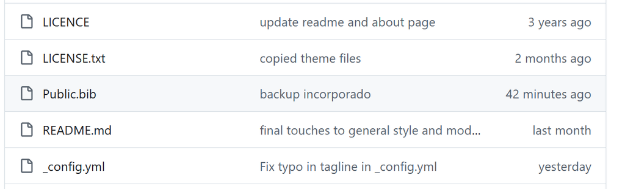

    - 6e1d40804c8c1d4080622d12d3c6ca7a.png

  - Haz click en “descargar” en la esquina superior derecha. Recuerda la ubicación pues lo necesitarás en el próximo paso.

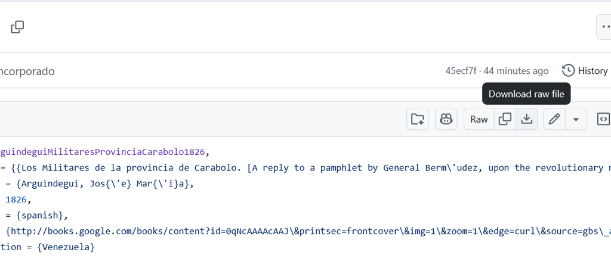

    - caafd8d461fbf490cbf344e3d8e0178b.png

  - En la barra superior haz click en “Acciones” y ahí haz click en el botón verde grande, para habilitarlas.

[figure not shown]

    - 2368f689ed68081f9391038bd4d3cc10.png

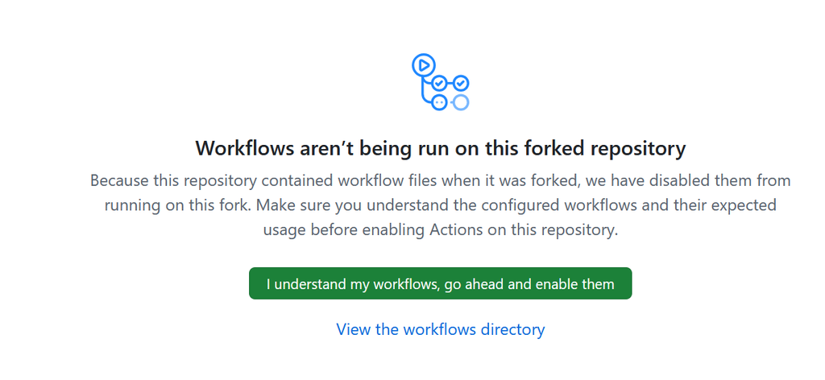

    - c14bc43bb7a87586f819b3edd92c3158.png

  - Vuelve a “código” en la esquina superior izquierda, abre el archivo `_config.yml` y selecciona “editar” en la esquina superior derecha

[figure not shown]

    - 5ae869c48ffee42538c4fd835624de4a.png

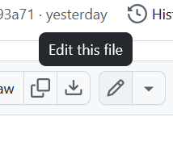

    - a436729ac772b8053ca10ae00430efd5.png

  - Edita los campos `title` y `tagline` con información sobre tu curso, seminario o taller. Debes hacer al menos un pequeño cambio para que se dispare la generación del sitio. Cuando hayas hecho el cambio haz click en el botón verde en la esquina superior derecha, para confirmar cambios

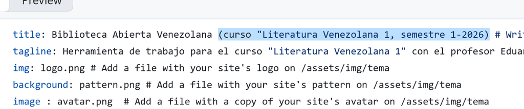

    - c9c8169fa6c64c12cc7258c63d26e4bd.png

[figure not shown]

    - 9b1f8706931f822eb7a2a37608dcad05.png

  - ¡Casi listo! Solo tienes que esperar unos minutos a que el sitio se genere. Ve a “configuración” en la esquina superior derecha y busca en la barra lateral la opción de “páginas”. Ahí, selecciona la rama `gh-pages` para generar el sitio. No olvides guardar para terminar.

[figure not shown]

    - 426a61a6e2661fce8c1bb2f4ab1dfcf5.png

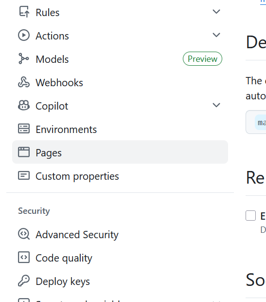

    - eb49fd25d4ba8afe50a1c490494a0a51.png

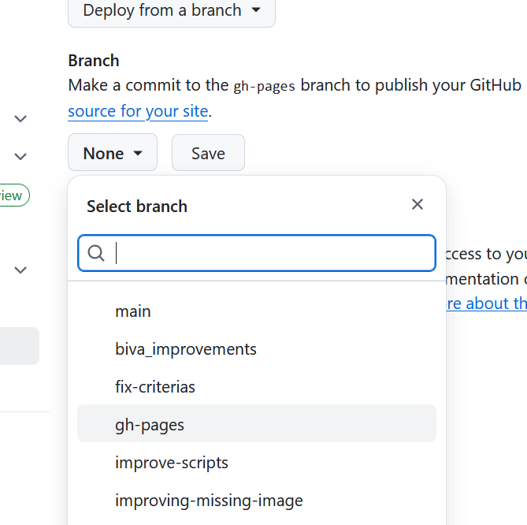

    - 5a496ab9a43f207dc62550966714e0ed.png

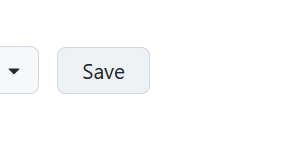

    - b946ea061537784dcebb0eabb305402a.png

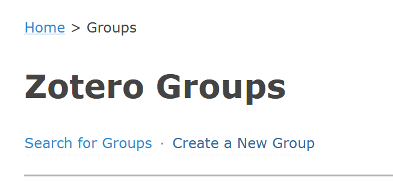

  - Elige la privacidad. La recomendable es la segunda: público con membresía cerrada. Mantén la configuración predeterminada.

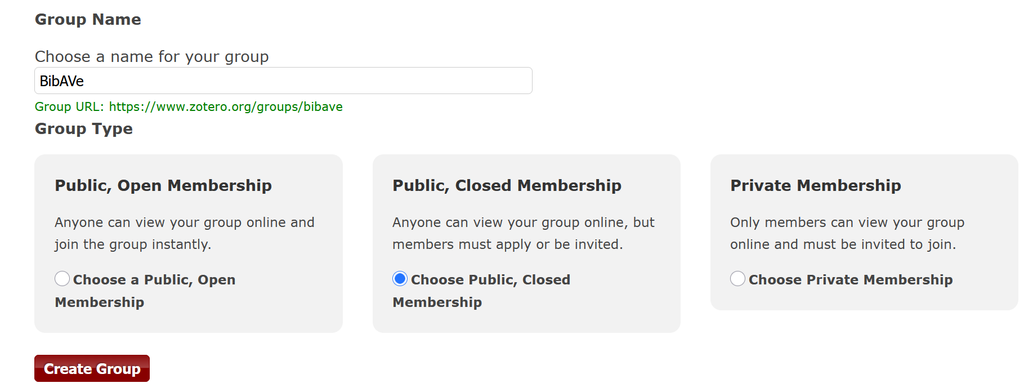

  - Ve a la configuración de miembros, y envía una invitación a tus estudiantes

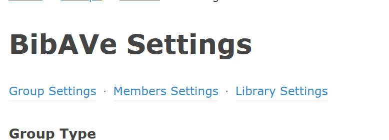

    - 85fcef3f459f0df313a3b447b37d74df.png

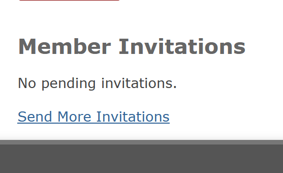

    - 744e6e823f7d72f7ec39c59c9d1185a6.png

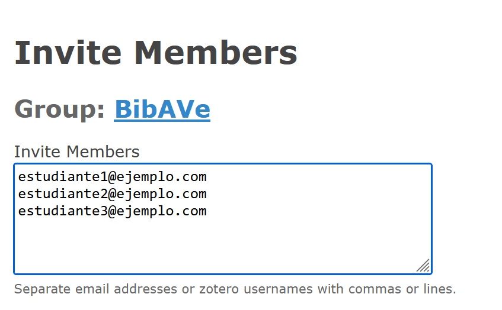

    - c1915b47180cc5fa828589b1a8cdd6aa.png

  - Abre tu cliente Zotero de escritorio (local) y encuentra en la columna izquierda el grupo que acabas de crear. Selecciónalo.

[figure not shown]

    - 8aae1099caa7583cdcfb5e86a19c224d.png

  - Ve a `Archivo > Importar...` y selecciona el archivo `Public.bib` que descargaste de GitHub

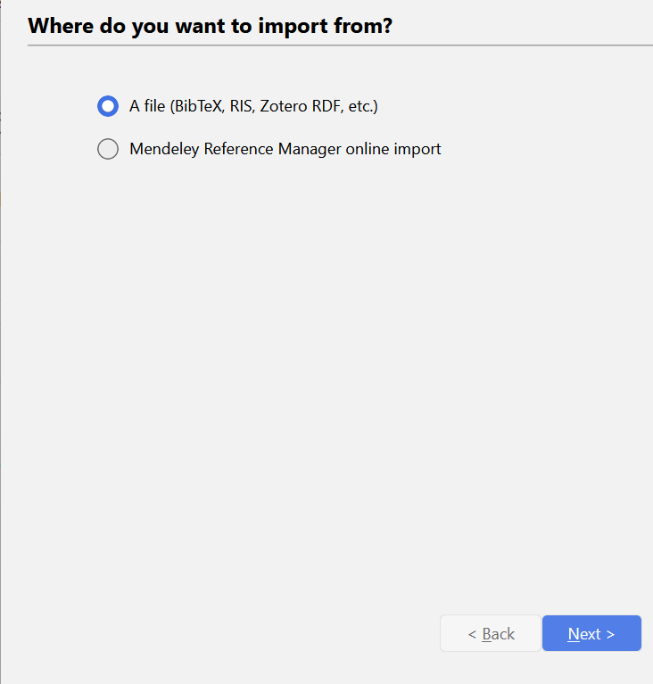

    - 0b5950f99a66143467ca3c4af00499fe.png

[figure not shown]

    - d6e816ff5ca1d9f172466780e8c6cc6a.png

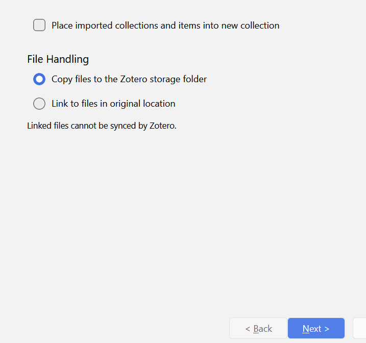

    - 824fea1a264a8e1564cc3263c6d59e6a.png

  - Ya tienes una copia de BibAV lista para trabajar en el aula de clases, que estará sincronizándose con tu biblioteca grupal en línea. Ahora solo queda enlazarla a la página que creaste en el primer paso.
- Enlazando la biblioteca grupal al sitio web
  - Vuelve a Zotero y elige “grupos” en el menú principal

[figure not shown]

    - 0e666921635c7cf8001f1a3f8a39164a.png

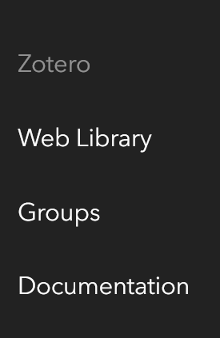

    - df6642e3f83bcf87439897ac889b25b7.png

  - Copia el número que aparece en la url del grupo

[figure not shown]

    - febdf3c40cd07433afac941b25b0c3bb.png

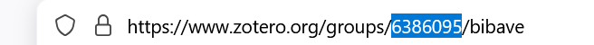

    - e4c98282222e3bb66984e02d9f38e859.png

  - Vuelve a la página del repositorio, que guardaste en “favoritos”, y abre el archivo `_config.yml`